# **Projecto de análises de dados para depósitos aluvionares**

### **Tp**

```python
df_tp_mean = df.groupby(["Deposito"])['Tp'].mean().reset_index().round(2)
df_tp_mean.set_index('Deposito', inplace=True)
```

[output not shown]

[figure not shown]

```python
width = 40 # width of chart
heigth = 10 # heigth chart
dataframe = df_tp_mean
column = 'Tp'

categories = df_tp_mean.index.values  # categories
values = df_tp_mean['Tp']         # corresponding values of categories

colormap = plt.cm.coolwarm       # Color map class


create_waffle_chart(categories, dataframe, column, values, heigth, width, colormap)
```

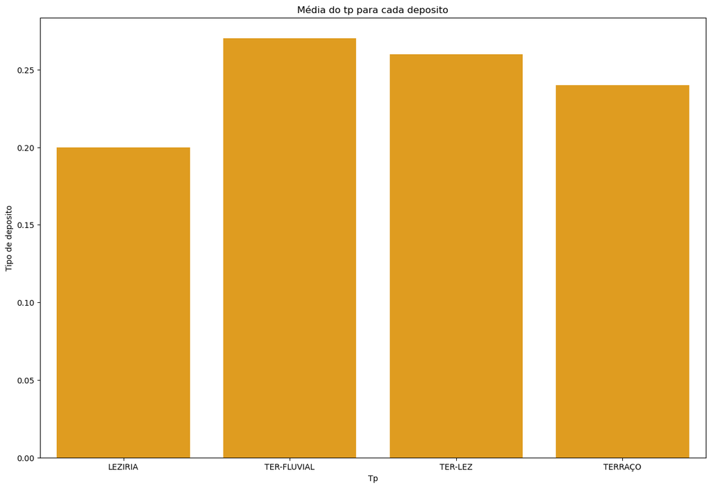

```python
plt.figure(figsize=(15, 10))
srn.barplot(x='Deposito', y='Tp', color='orange', data=df_tp_mean)

plt.title('Média do tp para cada deposito')
plt.xlabel('Tp')
plt.ylabel('Tipo de deposito')

plt.show()
```

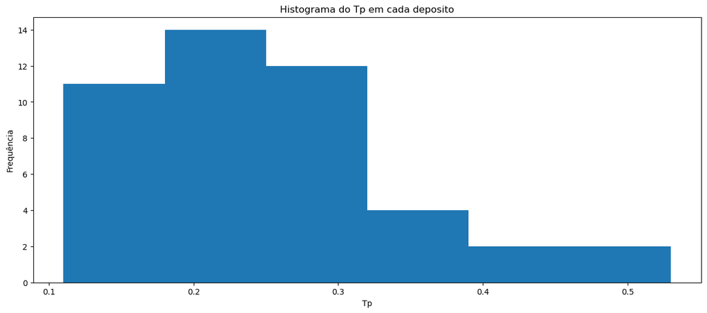

```python
df['Tp'].plot(kind='hist', bins=6, figsize=(15, 6))

plt.title('Histograma do Tp em cada deposito')
plt.xlabel('Tp')
plt.ylabel('Frequência')

plt.show()
```

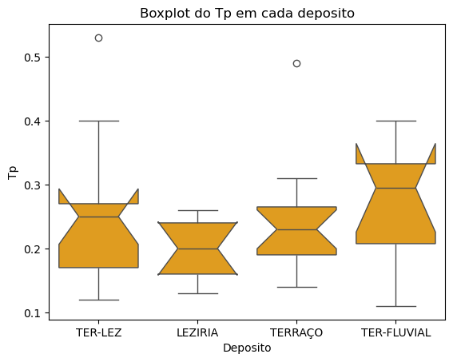

```python
# Boxplot para as colunas 'Deposito' e 'Volume'.
df['Deposito'].unique()

srn.boxplot(x='Deposito',
            y='Tp',
            data=df,
            orient='v',
            color='orange',
            notch=True).set_title('Boxplot do Tp em cada deposito')

plt.show()
```

[figure not shown]

```python
color_list = ['gold', 'yellowgreen', 'blue', 'lightskyblue']

explode_list = [0, 0.1, 0, 0]

df_tp_mean['Tp'].plot(kind='pie',
                            figsize=(15, 6),
                            autopct='%1.1f%%',
                            startangle=90,
                            #shadow=True,
                            labels=None,
                            pctdistance=1.20,
                            explode=explode_list
                            )


# scale the title up by 12% to match pctdistance
plt.title('% do teor em cada deposito', y=1.10)

# Sets the pie chart to look like a circle.
plt.axis('equal')

# Add legend
plt.legend(labels=df_tp_mean.index, loc='upper left', fontsize=7)

plt.show()
```

[figure not shown]

```python
srn.kdeplot(df.Tp, shade=True, color='orange')
plt.ylabel('Frequency')
plt.xlabel('Teor')

plt.show()
```

#### **Relação entre as variáveis**

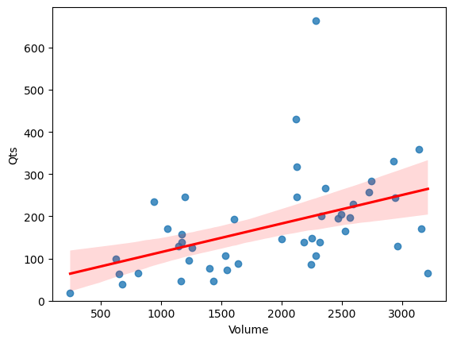

```python
srn.regplot(x='Volume', y='Qts', data=df, line_kws={'color': 'red'})
plt.ylim(0,)
plt.show()
```

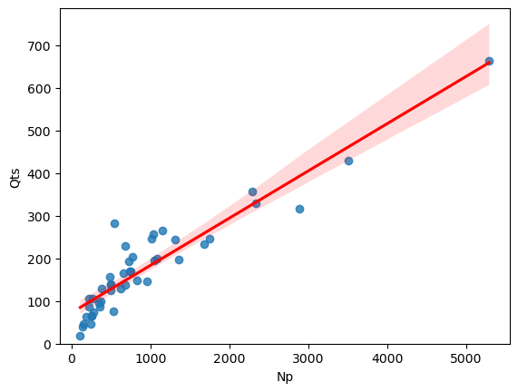

```python
srn.regplot(x='Np', y='Qts', data=df, line_kws={'color': 'red'})
plt.ylim(0,)
plt.show()
```

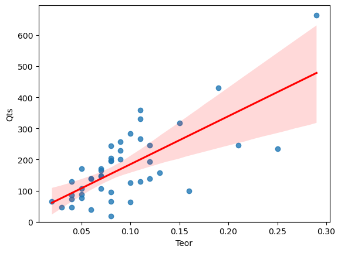

```python
srn.regplot(x='Teor', y='Qts', data=df, line_kws={'color': 'red'})
plt.ylim(0,)
plt.show()
```

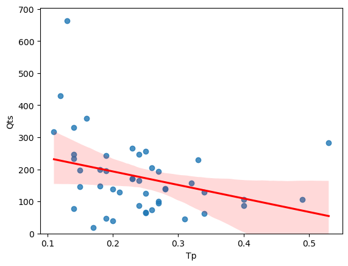

```python
srn.regplot(x='Tp', y='Qts', data=df, line_kws={'color': 'red'})
plt.ylim(0,)
plt.show()
```

**Conclusão da análise explorátoria**

A análise dos dados revelou padrões significativos na recuperação de diamantes nos diferentes tipos de depósitos aluvionares.

🔹 Maior Volume de Minério Processado: O Depósito de Terraço destacou-se como o mais processado, representando 36% do volume total tratado.

🔹 Maior Recuperação de Pedras: O Depósito de Lezíria apresentou a maior recuperação de diamantes em número de pedras, correspondendo a 27% do total recuperado.

🔹 Teor Médio Recuperado: Os Depósitos de Terraço e Transição se destacaram, cada um representando 26.3% da média total de teor recuperado, evidenciando uma maior concentração de diamantes nesses ambientes.

Análise do Depósito de Terraço-Fluvial Dentre os depósitos analisados, o Depósito de Terraço-Fluvial demonstrou menor destaque nos indicadores de recuperação, possivelmente devido à sua formação geológica. Algumas hipóteses para esse comportamento incluem:

- 1. Alta dispersão do material, dificultando a concentração de diamantes.
- 2. Discontinuidade na deposição dos sedimentos, impactando a uniformidade do depósito.
- 3. Baixa energia de transporte dos sedimentos, reduzindo a capacidade de concentração de material diamantífero.

[EN]

**Conclusion of the exploratory analysis**

The data analysis revealed significant patterns in the recovery of diamonds in the different types of alluvial deposits.

🔹 Largest Volume of Ore Processed: The Terraço Deposit stood out as the most processed, representing 36% of the total volume treated.

🔹 Largest Stone Recovery: The Lezíria Deposit presented the highest diamond recovery in number of stones, corresponding to 27% of the total recovered.

🔹 Average Recovered Grade: The Terrace and Transition Deposits stood out, each representing 26.3% of the total average recovered grade, evidencing a higher concentration of diamonds in these environments.

Analysis of the Terrace-Fluvial Deposit Among the deposits analyzed, the Terrace-Fluvial Deposit demonstrated less prominence in the recovery indicators, possibly due to its geological formation. Some hypotheses for this behavior include:

- 1. High dispersion of the material, making it difficult to concentrate diamonds.
- 2. Discontinuity in the deposition of sediments, impacting the uniformity of the deposit.
- 3. Low transport energy of the sediments, reducing the capacity to concentrate diamond-bearing material.

#### **Quarta Tarefa**

- Model Development
  - Simple Linear Regression
  - Multiple Linear Regression
  - Polynomial Regression
  - Ridge Regression

```python
lm = LinearRegression()
lm
```

```
LinearRegression()
```

- **Simple Linear Regression**

Podemos ajustar o modelo de regressão linear usando a variável que ''apresenta'' menos correlação com a variável que queremos prever. Nesse caso os quilates.

## **LEZIRIA DEPOSITO**

```python
LEZIRIA = df.loc[df['Deposito'] == 'LEZIRIA']
```

- **Volume**

```python
x_lez1 = LEZIRIA[['Volume']]
Y_lez = LEZIRIA['Qts']
```

```python
lr_lez1 = lm.fit(x_lez1,Y_lez)
lr_lez1
```

```
LinearRegression()
```

```python
# Produce a prediction
Yhat_lr_lez1 = lr_lez1.predict(x_lez1)
Yhat_lr_lez1[0:5].round(2)
```

```
array([ 46.42, 101.34, 144.11, 254.63, 325.53])
```

```python
# Final Estimaded Linear for the model above
qts_lr_lez1 = lr_lez1.intercept_ + lr_lez1.coef_ * LEZIRIA['Volume']
qts_lr_lez1[0:5].round(2)
```

```
1      46.42
6     101.34
10    144.11
22    254.63
26    325.53
Name: Volume, dtype: float64
```

```python
# Calculate de R^2
R_squared_lr1 = r2_score(Y_lez, lr_lez1.predict(x_lez1))
print('R_squared is:', R_squared_lr1)
```

```
R_squared is: 0.2368213939364504
```

[EN]

- **Teor**

```python
x_lez2 = LEZIRIA[['Teor']]
```

```python
# Ajustar o modelo com uma nova variável
lr_lez2 = lm.fit(x_lez2, Y_lez)
lr_lez2
```

```
LinearRegression()
```

```python
# Produce a prediction
Yhat_lr_lez2 = lr_lez2.predict(x_lez2)
Yhat_lr_lez2[0:5].round(2)
```

```
array([135.4 ,  87.24,  87.24, 159.48, 111.32])
```

```python
# Final Estimaded Linear for the second model (lr2)
qts_lr_lez2 = lr_lez2.intercept_ + lr_lez2.coef_ * LEZIRIA['Teor']
qts_lr_lez2[0:5].round(2)
```

```
1     135.40
6      87.24
10     87.24
22    159.48
26    111.32
Name: Teor, dtype: float64
```

```python
# Calculate de R^2
R_squared_lr2 = lr_lez2.score(x_lez2, Y_lez)
print('R_squared is:', R_squared_lr2 )
```

```
R_squared is: 0.9148621448957358
```

**Conclusão**:

O valor do erro quadrático para o modelo de regressão linear com a variável `Volume` é relativamente menor que em relação ao erro quadrático para a modelo usando a variável `Teor`. Isso significa que o segundo modelo é o melhor para prever os quilates a serem recuperados.

[EN]

**Conclusion**:

The squared error value for the linear regression model with the `Volume` variable is relatively smaller than the squared error for the model using the `Grade` variable. This means that the second model is the best for predicting the carats to be recovered.

- **Multiple Linear Regression**:

Podemos ajustar o modelo de regressão linear para prever o quantidade de quilates a recuperar usando todas as demais variáveis:

- `Volume`, `Teor`.

[EN]

We can fit the linear regression model to predict the amount of carats to recover using all the other variables:

- `Volume`, `Grade`.

```python
Z_lez1 = LEZIRIA[['Volume', 'Teor']]
```

```python
lr_lez3 = lm.fit(Z_lez1, Y_lez)
lr_lez3
```

```
LinearRegression()
```

```python
Yhat_lr_lez3 = lr_lez3.predict(Z_lez1)
Yhat_lr_lez3[0:5].round(2)
```

```
array([ 46.58,  33.6 ,  58.45, 190.04, 186.35])
```

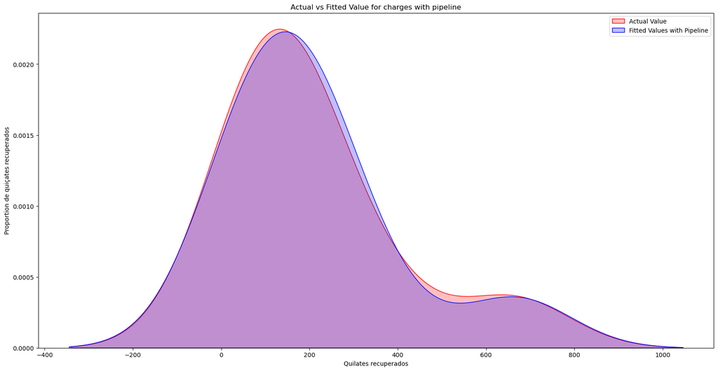

```python
plt.figure(figsize=(20, 10))

ax1 = srn   .kdeplot(Y_lez, color='r', label='Actual Value', fill=True)
srn.kdeplot(Yhat_lr_lez3, color='b', label='Fitted Values with Pipeline',fill=True, ax=ax1)

plt.title('Actual vs Fitted Value for charges with pipeline')
plt.xlabel('Quilates recuperados')
plt.ylabel('Proportion de quiçates recuperados')

plt.legend()

plt.show()
```

```python
R_squared_lr3 = lr_lez3.score(Z_lez1, Y_lez)
print('R_squared is:', R_squared_lr3)
```

```
R_squared is: 0.9906743285901429
```

**Conclusion**:

- Podemos observar que o valor do erro quadrático para o modelo de regressão linear múltipla é maior em relação ao erro quadrádito do modelo de regressão linear simples.

Continuaremos a procurar qual é o melhor ajuste. Para isso usaremos Regressão Polinomial e a Regressão de Ridge.

[EN]

**Conclusion**:

- We can see that the squared error value for the multiple linear regression model is higher than the squared error of the simple linear regression model.

We will continue to look for the best fit. For this we will use Polynomial Regression and Ridge Regression.

**Regressão Polinomial**

- Agora iremos crear um objeto de pipeline para prever os quilates, ajustar o objeto usando as variáveis na lista de variáveis criada e calcular o erro quadrático.
- Para fazer isso iremos usar a função variável polinomial para transformar as variáveis dentro da funcão variável polinomal com um grão igual a 2.

```python
# Create a polynomial feature obbject of degree 2
pr_lez1 = PolynomialFeatures(degree=2)
print(pr_lez1)
```

```
PolynomialFeatures()
```

```python
Z_lez1.isnull().sum()
```

```
Volume    0
Teor      0
dtype: int64
```

```python
# Fit and transform the data into a polynomial
Z_pr_lez1 = pr_lez1.fit_transform(Z_lez1)
print(Z_lez1.shape)
print(Z_pr_lez1.shape)
```

```
(9, 2)
(9, 6)
```

- Criar a pipeline, pela criando de uma lista de tuples incluindo o nome do modelo e isso corresponde a construção do input.

```python
input_lez = [('Scale', StandardScaler()), ('Polynomial', PolynomialFeatures(include_bias=False)), ('model', LinearRegression())]
input_lez
```

```
[('Scale', StandardScaler()),
 ('Polynomial', PolynomialFeatures(include_bias=False)),
 ('model', LinearRegression())]
```

Inserir a lista como um argumento do construtor pipeline:

```python
pipe_lez = Pipeline(input_lez)
pipe_lez
```

```
Pipeline(steps=[('Scale', StandardScaler()),
                ('Polynomial', PolynomialFeatures(include_bias=False)),
                ('model', LinearRegression())])
```

- **Normalizando os dados por que regressão polinomial é sensível as escalas das variáveis.**

```python
feature_lez1 = Z_lez1.astype(float)
pipe_lez.fit(feature_lez1, Y_lez)
```

```
Pipeline(steps=[('Scale', StandardScaler()),
                ('Polynomial', PolynomialFeatures(include_bias=False)),
                ('model', LinearRegression())])
```

```python
Yhat_pipe_lez = pipe_lez.predict(feature_lez1)
Yhat_pipe_lez[0:5]
```

```
array([ 39.46040026,  52.06728139,  66.96607013, 180.69024147,
       168.25478548])
```

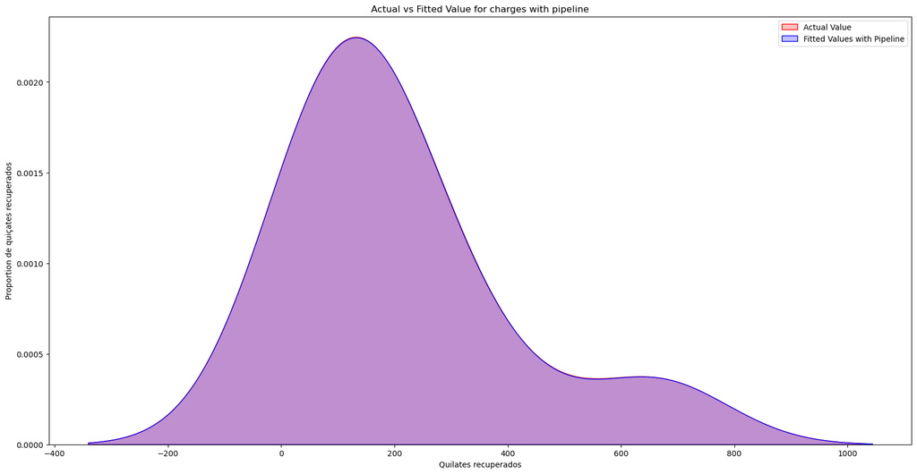

```python
plt.figure(figsize=(20, 10))

ax1 = srn   .kdeplot(Y_lez, color='r', label='Actual Value', fill=True)
srn.kdeplot(Yhat_pipe_lez, color='b', label='Fitted Values with Pipeline',fill=True, ax=ax1)

plt.title('Actual vs Fitted Value for charges with pipeline')
plt.xlabel('Quilates recuperados')
plt.ylabel('Proportion de quiçates recuperados')

plt.legend()

plt.show()
```

```python
R_squared_pipe_lez = r2_score(Y_lez, pipe_lez.predict(feature_lez1))
print('R_squared:', R_squared_pipe_lez)
```

```
R_squared: 0.9988093462798296
```

**Conclusion**:

- O valor do erro quadrático do modelo polinomial é maior em relação ao modelo de regressão linear simples e múltipla. Isso significa que o modelo de regressão polinomial é melhor em prever a recuperação de quilates.

[EN]

**Conclusion**:

- The squared error value of the polynomial model is higher than that of the simple and multiple linear regression models. This means that the polynomial regression model is better at predicting carat recovery.

#### **Quinta Tarefa**

- Avaliação e Ajustamento do Modelo

```python
features_lez2 =  ['Volume', 'Teor']
Z_lez2 = LEZIRIA[features_lez2]
```

[EN]

```python
x_train_lez, x_test_lez, y_train_lez, y_test_lez = train_test_split(Z_lez2, Y_lez, test_size=0.15, random_state=1)

print('Number of training samples:', x_train_lez.shape[0])
print('Number of test samples:', x_test_lez.shape[0])
```

```
Number of training samples: 7
Number of test samples: 2
```

- Criar o object de Regressão Ridge.
- Usando os dados do treinamento, adiciona o parametro de regularização para 0.1
- Porque estou usando a Regressão Ridge ?
  - A Regressão Ridge é o tipo de regressão linear que pode ser usado

  quando a multicolinariedade está presente nos dados. Isto é algo bom para prever super ajustes, porque introduz uma quantía pequena de bias no modelo.

[EN]

- Create the Ridge Regression object.
- Using the training data, add the regularization parameter to 0.1
- Why am I using Ridge Regression?
- Ridge Regression is the type of linear regression that can be used

when multicollinearity is present in the data. This is a good thing for predicting overfitting, because it introduces a small amount of bias into the model.

```python
RidgeModelo_lez = Ridge(alpha=0.1)
RidgeModelo_lez.fit(x_train_lez, y_train_lez)
```

```
Ridge(alpha=0.1)
```

```python
R_squared_Ridge = r2_score(y_test_lez, RidgeModelo_lez.predict(x_test_lez))
print('The R-squared value is:', R_squared_Ridge)
```

```
The R-squared value is: -0.31214783059245965
```

- Criar as variáveis polinomias e transformar sub-conjuntos de treinamento e de teste.
- Performando a tranformação do 2º grão polinomial nos dados.

[EN]

```python
pr_lez2 = PolynomialFeatures(degree=2)
x_train_pr_lez2 = pr_lez2.fit_transform(x_train_lez)
x_test_pr_lez2 = pr_lez2.fit_transform(x_test_lez)
pr_lez2
```

```
PolynomialFeatures()
```

```python
print(x_train_pr_lez2.shape)
print(x_test_pr_lez2.shape)
```

```
(7, 6)
(2, 6)
```

- Ajustando o RidgeModelo criado em cima com o PolynomialFeatures (pr2)

[EN]

- Adjusting the RidgeModel created above with PolynomialFeatures (pr2)

```python
RidgeModelo_lez.fit(x_train_pr_lez2, y_train_lez)
```

```
Ridge(alpha=0.1)
```

Nós usaremos o método `predict` para prever os quilates recuperados nas dados de treinamentos e nos dados de test.

[EN]

We will use the `predict` method to predict the recovered carats in the training data and the test data.

- **Treinamento / Training**

```python
Yhat_Ridge_Polly_lez = RidgeModelo_lez.predict(x_train_pr_lez2)
Yhat_Ridge_Polly_lez[0:5]
```

```
array([139.23386558, 356.6372051 ,  44.80258778,  41.59328475,
       167.75020999])
```

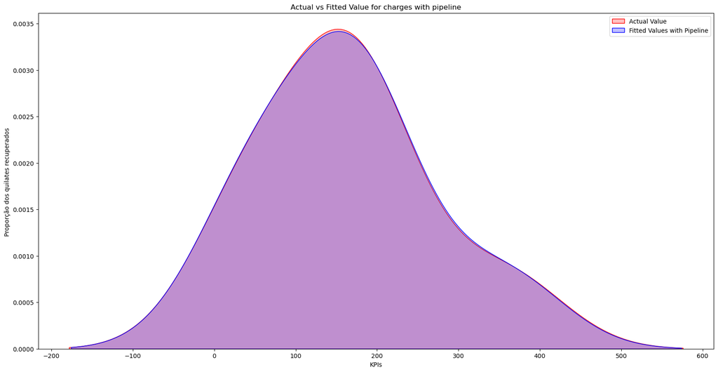

```python
plt.figure(figsize=(20, 10))

ax1 = srn.kdeplot(y_train_lez, color='r', label='Actual Value', fill=True)
srn.kdeplot(Yhat_Ridge_Polly_lez, color='b', label='Fitted Values with Pipeline', fill=True, ax=ax1)

plt.title('Actual vs Fitted Value for charges with pipeline')
plt.xlabel('KPIs')
plt.ylabel('Proporção dos quilates recuperados ')

plt.legend()

plt.show()
```

```python
R_squared_Ridge_Polly = r2_score(y_train_lez, Yhat_Ridge_Polly_lez)
print('The R-Squared value is:', R_squared_Ridge_Polly)
```

```
The R-Squared value is: 0.9958580355564585
```

- **Teste**

```python
Yhat_Ridge_Polly_lez_test = RidgeModelo_lez.predict(x_test_pr_lez2)
Yhat_Ridge_Polly_lez_test[0:5]
```

```
array([666.78123548,  59.4152653 ])
```

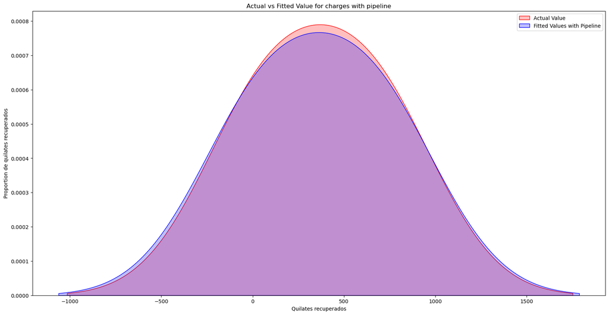

```python
plt.figure(figsize=(20, 10))

ax1 = srn   .kdeplot(y_test_lez, color='r', label='Actual Value', fill=True)
srn.kdeplot(Yhat_Ridge_Polly_lez_test, color='b', label='Fitted Values with Pipeline',fill=True, ax=ax1)

plt.title('Actual vs Fitted Value for charges with pipeline')
plt.xlabel('Quilates recuperados')
plt.ylabel('Proportion de quilates recuperados')

plt.legend()

plt.show()
```

```python
R_squared_Ridge_Polly = r2_score(y_test_lez, Yhat_Ridge_Polly_lez_test)
print('The R-Squared value is:', R_squared_Ridge_Polly)
```

```
The R-Squared value is: 0.9987885438112296
```

- **Validação Cruzada / Cross-Validation**
- Podemos usar o method `cross_val_score` para otber a media do erro quadrático para dados de treino e de test.

[EN]

- We can use the `cross_val_score` method to get the mean squared error for training and test data.

```python
Rcross_Polly = cross_val_score(RidgeModelo_lez, x_train_pr_lez2, y_train_lez, cv = 3)
print('The mean of the folds are:', Rcross_Polly.mean())
```

```
The mean of the folds are: 0.32433261548746944
```

## **TER-LEZ DEPOSITO / TRANSITION DEPOSIT**

```python
TER_LEZ = df.loc[df['Deposito'] == 'TER-LEZ']
```

- **Regressão Linear**
- **Volume**

```python
x_ter_lez1 = TER_LEZ[['Volume']]
Y_ter_lez = TER_LEZ['Qts']
```

```python
lr_ter_lez1 = lm.fit(x_ter_lez1, Y_ter_lez)
lr_ter_lez1
```

```
LinearRegression()
```

```python
# Produce a prediction
Yhat_lr_ter_lez1 = lr_ter_lez1.predict(x_ter_lez1)
Yhat_lr_ter_lez1[0:5].round(2)
```

```
array([ 28.76,  85.51, 158.37, 127.78,  67.  ])
```

```python
# Final Estimaded Linear for the model above
Yhat_lr_ter_lez1 = lr_ter_lez1.intercept_ + lr_ter_lez1.coef_ * TER_LEZ['Volume']
Yhat_lr_ter_lez1[0:5].round(2)
```

```
0      28.76
7      85.51
9     158.37
11    127.78
13     67.00
Name: Volume, dtype: float64
```

```python
# Calculate de R^2
R_squared_lr1 = r2_score(Y_ter_lez, lr_ter_lez1.predict(x_ter_lez1))
print('R_squared is:', R_squared_lr1)
```

```
R_squared is: 0.571712853386504
```

- **Teor**

```python
x_ter_lez2 = TER_LEZ[['Teor']]
```

```python
# Ajustar o modelo com uma nova variável
lr_ter_lez2 = lm.fit(x_ter_lez2, Y_ter_lez)
lr_ter_lez2
```

```
LinearRegression()
```

```python
# Produce a prediction
Yhat_lr_ter_lez2 = lr_ter_lez2.predict(x_ter_lez2)
Yhat_lr_ter_lez2[0:5].round(2)
```

```
array([129.28, 129.28, 111.31, 129.28, 273.06])
```

```python
# Final Estimaded Linear for the model above
qts_lr_ter_lez2 = lr_ter_lez2.intercept_ + lr_ter_lez2.coef_ * TER_LEZ['Teor']
qts_lr_ter_lez2[0:5].round(2)
```

```
0     129.28
7     129.28
9     111.31
11    129.28
13    273.06
Name: Teor, dtype: float64
```

```python
# Calculate de R^2
R_squared_lr2 = lr_ter_lez2.score(x_ter_lez2, Y_ter_lez)
print('R_squared is:', R_squared_lr2 )
```

```
R_squared is: 0.3434640523062198
```

- **Multiple Linear Regression**:

```python
Z_ter_lez1 = TER_LEZ[['Volume', 'Teor']]
```

```python
lr_ter_lez3 = lm.fit(Z_ter_lez1, Y_ter_lez)
lr_ter_lez3
```

```
LinearRegression()
```

```python
# Produce a prediction
Yhat_lr_ter_lez3 = lr_ter_lez3.predict(Z_ter_lez1)
Yhat_lr_ter_lez3[0:5].round(2)
```

```
array([-13.5 ,  43.84,  99.18,  86.55, 171.41])
```

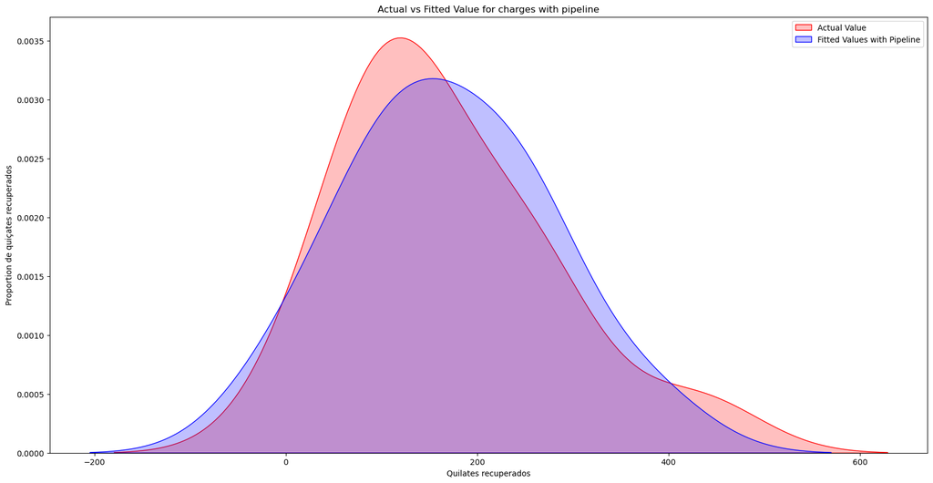

```python
plt.figure(figsize=(20, 10))

ax1 = srn   .kdeplot(Y_ter_lez, color='r', label='Actual Value', fill=True)
srn.kdeplot(Yhat_lr_ter_lez3, color='b', label='Fitted Values with Pipeline',fill=True, ax=ax1)

plt.title('Actual vs Fitted Value for charges with pipeline')
plt.xlabel('Quilates recuperados')
plt.ylabel('Proportion de quiçates recuperados')

plt.legend()

plt.show()
```

```python
R_squared_lr3 = lr_ter_lez3.score(Z_ter_lez1 , Y_ter_lez)
print('R_squared is:', R_squared_lr3)
```

```
R_squared is: 0.9271313124708324
```

Continuaremos a procurar qual é o melhor ajuste. Para isso usaremos Regressão Polinomial e a Regressão de Ridge.

[EN]

We will continue to look for the best fit. For this we will use Polynomial Regression and Ridge Regression.

**Regressão Polinomial**

```python
# Create a polynomial feature obbject of degree 2
pr_ter_lez1 = PolynomialFeatures(degree=2)
print(pr_ter_lez1)
```

```
PolynomialFeatures()
```

```python
Z_ter_lez1.isnull().sum()
```

```
Volume    0
Teor      0
dtype: int64
```

```python
# Fit and transform the data into a polynomial
Z_pr_ter_lez1 = pr_ter_lez1.fit_transform(Z_ter_lez1)
print(Z_ter_lez1.shape)
print(Z_pr_ter_lez1.shape)
```

```
(13, 2)
(13, 6)
```

```python
input_ter_lez = [('Scale', StandardScaler()), ('Polynomial', PolynomialFeatures(include_bias=False)), ('model', LinearRegression())]
input_ter_lez
```

```
[('Scale', StandardScaler()),
 ('Polynomial', PolynomialFeatures(include_bias=False)),
 ('model', LinearRegression())]
```

```python
pipe_ter_lez = Pipeline(input_ter_lez)
pipe_ter_lez
```

```
Pipeline(steps=[('Scale', StandardScaler()),
                ('Polynomial', PolynomialFeatures(include_bias=False)),
                ('model', LinearRegression())])
```

```python
feature_ter_lez1 = Z_ter_lez1.astype(float)
pipe_ter_lez.fit(feature_ter_lez1, Y_ter_lez)
```

```
Pipeline(steps=[('Scale', StandardScaler()),
                ('Polynomial', PolynomialFeatures(include_bias=False)),
                ('model', LinearRegression())])
```

```python
Yhat_pipe_ter_lez = pipe_ter_lez.predict(feature_ter_lez1)
Yhat_pipe_ter_lez[0:5]
```

```
array([ 22.95802006,  63.24780355, 102.64006787,  94.81460569,
       100.48202909])
```

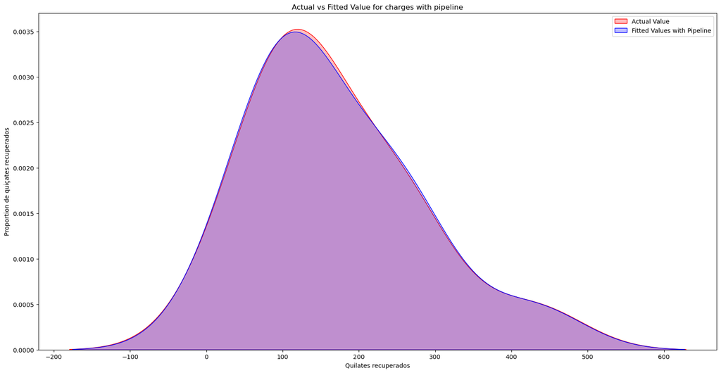

```python
plt.figure(figsize=(20, 10))

ax1 = srn   .kdeplot(Y_ter_lez, color='r', label='Actual Value', fill=True)
srn.kdeplot(Yhat_pipe_ter_lez, color='b', label='Fitted Values with Pipeline',fill=True, ax=ax1)

plt.title('Actual vs Fitted Value for charges with pipeline')
plt.xlabel('Quilates recuperados')
plt.ylabel('Proportion de quiçates recuperados')

plt.legend()

plt.show()
```

```python
R_squared = r2_score(Y_ter_lez, pipe_ter_lez.predict(feature_ter_lez1))
print('R_squared:', R_squared)
```

```
R_squared: 0.9972367427865375
```

#### **Quinta Tarefa / 5º Task**

- Avaliação e Ajustamento do Modelo / Validation and Model Refinement

```python
features_ter_lez2 =  ['Volume', 'Teor']
Z_ter_lez2 = TER_LEZ[features_ter_lez2]
```

```python
x_train_ter_lez, x_test_ter_lez, y_train_ter_lez, y_test_ter_lez = train_test_split(Z_ter_lez2, Y_ter_lez, test_size=0.15, random_state=1)

print('Number of training samples:', x_train_ter_lez.shape[0])
print('Number of test samples:', x_test_ter_lez.shape[0])
```

```
Number of training samples: 11
Number of test samples: 2
```

```python
RidgeModelo_ter_lez = Ridge(alpha=0.1)
RidgeModelo_ter_lez.fit(x_train_ter_lez, y_train_ter_lez)
```

```
Ridge(alpha=0.1)
```

```python
R_squared_Ridge = r2_score(y_test_ter_lez, RidgeModelo_ter_lez.predict(x_test_ter_lez))
print('The R-squared value is:', R_squared_Ridge)
```

```
The R-squared value is: -61.462546273699914
```

```python
pr_ter_lez2 = PolynomialFeatures(degree=2)
x_train_pr_ter_lez2 = pr_ter_lez2.fit_transform(x_train_ter_lez)
x_test_pr_ter_lez2 = pr_ter_lez2.fit_transform(x_test_ter_lez)
pr_ter_lez2
```

```
PolynomialFeatures()
```

```python
print(x_train_pr_ter_lez2.shape)
print(x_test_pr_ter_lez2.shape)
```

```
(11, 6)
(2, 6)
```

```python
RidgeModelo_ter_lez.fit(x_train_pr_ter_lez2, y_train_ter_lez)
```

```
Ridge(alpha=0.1)
```

- **Treinamento / Training**

```python
Yhat_Ridge_Polly_ter_lez = RidgeModelo_ter_lez.predict(x_train_pr_ter_lez2)
Yhat_Ridge_Polly_ter_lez[0:5]
```

```
array([103.95550169, 203.1478924 ,  60.34400638, 121.56777435,
        21.72806105])
```

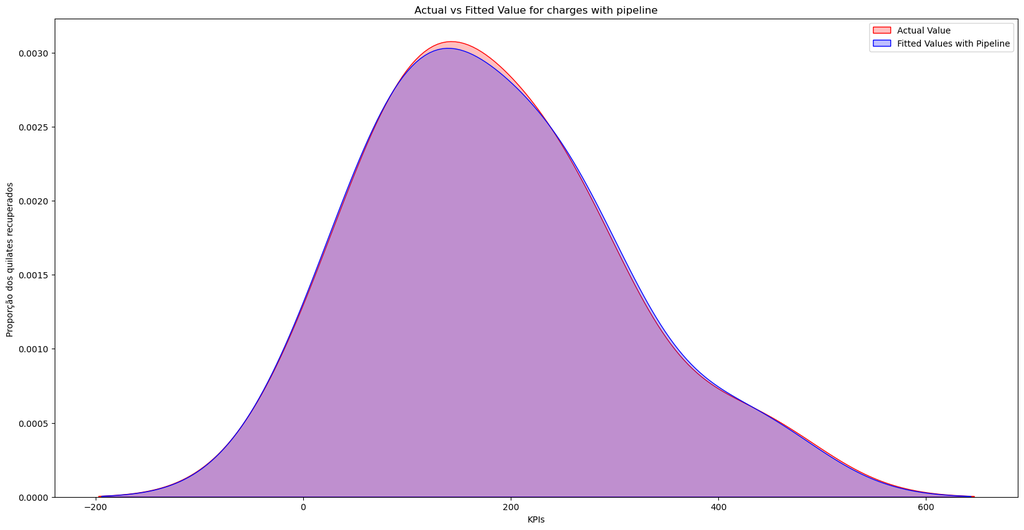

```python
plt.figure(figsize=(20, 10))

ax1 = srn.kdeplot(y_train_ter_lez, color='r', label='Actual Value', fill=True)
srn.kdeplot(Yhat_Ridge_Polly_ter_lez, color='b', label='Fitted Values with Pipeline', fill=True, ax=ax1)

plt.title('Actual vs Fitted Value for charges with pipeline')
plt.xlabel('KPIs')
plt.ylabel('Proporção dos quilates recuperados ')

plt.legend()

plt.show()
```

```python
R_squared_Ridge_Polly = r2_score(y_train_ter_lez, Yhat_Ridge_Polly_ter_lez)
print('The R-Squared value is:', R_squared_Ridge_Polly)
```

```
The R-Squared value is: 0.997080673522627
```

- **Teste / Test**

```python
Yhat_Ridge_Polly_ter_lez_test = RidgeModelo_ter_lez.predict(x_test_pr_ter_lez2)
Yhat_Ridge_Polly_ter_lez_test[0:5]
```

```
array([97.7737106 , 91.39984308])
```

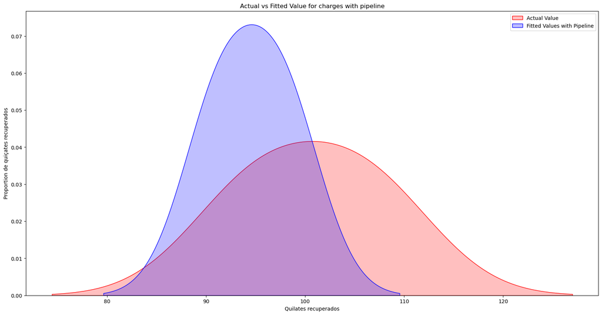

```python
plt.figure(figsize=(20, 10))

ax1 = srn.kdeplot(y_test_ter_lez, color='r', label='Actual Value', fill=True)
srn.kdeplot(Yhat_Ridge_Polly_ter_lez_test, color='b', label='Fitted Values with Pipeline',fill=True, ax=ax1)

plt.title('Actual vs Fitted Value for charges with pipeline')
plt.xlabel('Quilates recuperados')
plt.ylabel('Proportion de quiçates recuperados')

plt.legend()

plt.show()
```

```python
R_squared_Ridge_Polly = r2_score(y_test_ter_lez, Yhat_Ridge_Polly_ter_lez_test)
print('The R-Squared value is:', R_squared_Ridge_Polly)
```

```
The R-Squared value is: -0.3812739336521651
```

- **Validação Cruzada**

```python
Rcross_Polly = cross_val_score(RidgeModelo_ter_lez, x_train_pr_ter_lez2, y_train_ter_lez, cv = 3)
print('The mean of the folds are:', Rcross_Polly.mean())
```

```
The mean of the folds are: 0.9722505344319848
```

## **TERRAÇO DEPOSITO / TERRACE DEPOSIT**

```python
TER = df.loc[df['Deposito'] == 'TERRAÇO']
```

- **Regressão Linear / Regressão Linear**
- **Volume**

```python
x_ter1 = TER[['Volume']]
Y_ter = TER['Qts']
```

```python
lr_ter1 = lm.fit(x_ter1, Y_ter)
lr_ter1
```

```
LinearRegression()
```

```python
# Produce a prediction
Yhat_lr_ter1 = lr_ter1.predict(x_ter1)
Yhat_lr_ter1[0:5].round(2)
```

```
array([158.61, 152.81, 146.44, 153.06, 152.57])
```

```python
# Final Estimaded Linear for the model above
Yhat_lr_ter1 = lr_ter1.intercept_ + lr_ter1.coef_ * TER['Volume']
Yhat_lr_ter1[0:5].round(2)
```

```
2     158.61
4     152.81
8     146.44
12    153.06
16    152.57
Name: Volume, dtype: float64
```

```python
# Calculate de R^2
R_squared_lr1 = r2_score(Y_ter, lr_ter1.predict(x_ter1))
print('R_squared is:', R_squared_lr1)
```

```
R_squared is: 0.004460488784952643
```

- **Teor**

```python
x_ter2 = TER[['Teor']]
```

```python
# Ajustar o modelo com uma nova variável
lr_ter2 = lm.fit(x_ter2, Y_ter)
lr_ter2
```

```
LinearRegression()
```

```python
# Produce a prediction
Yhat_lr_ter2 = lr_ter2.predict(x_ter2)
Yhat_lr_ter2[0:5].round(2)
```

```
array([109.44, 125.38, 101.48, 117.41, 133.35])
```

```python
# Final Estimaded Linear for the model above
qts_lr_ter2 = lr_ter2.intercept_ + lr_ter2.coef_ * TER['Teor']
qts_lr_ter2[0:5].round(2)
```

```
2     109.44
4     125.38
8     101.48
12    117.41
16    133.35
Name: Teor, dtype: float64
```

```python
# Calculate de R^2
R_squared_lr2 = lr_ter2.score(x_ter2, Y_ter)
print('R_squared is:', R_squared_lr2 )
```

```
R_squared is: 0.5186702465936546
```

[EN]

**Conclusion**:

- **Multiple Linear Regression**:

```python
Z_ter1 = TER[['Volume', 'Teor']]
```

```python
lr_ter3 = lm.fit(Z_ter1, Y_ter)
lr_ter3
```

```
LinearRegression()
```

```python
# Produce a prediction
Yhat_lr_ter3 = lr_ter_lez3.predict(Z_ter1)
Yhat_lr_ter3[0:5].round(2)
```

```
array([ 42.13, 121.53, 144.68, 106.87, 136.12])
```

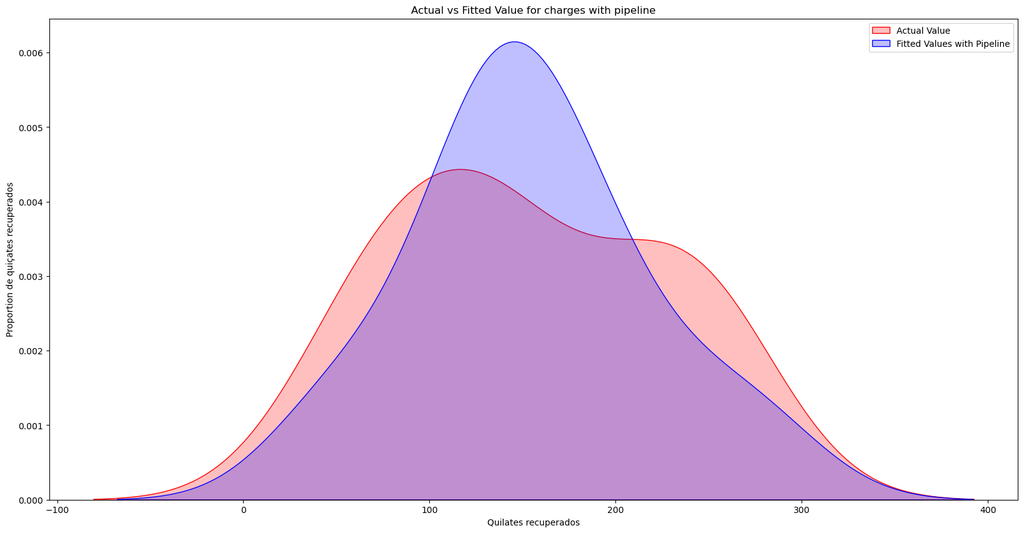

```python
plt.figure(figsize=(20, 10))

ax1 = srn   .kdeplot(Y_ter, color='r', label='Actual Value', fill=True)
srn.kdeplot(Yhat_lr_ter3, color='b', label='Fitted Values with Pipeline',fill=True, ax=ax1)

plt.title('Actual vs Fitted Value for charges with pipeline')
plt.xlabel('Quilates recuperados')
plt.ylabel('Proportion de quiçates recuperados')

plt.legend()

plt.show()
```

```python
R_squared_lr3 = lr_ter3.score(Z_ter1 , Y_ter)
print('R_squared is:', R_squared_lr3)
```

```
R_squared is: 0.760651589821771
```

**Regressão Polinomial / Polinomial Regression**

```python
# Create a polynomial feature obbject of degree 2
pr_ter1 = PolynomialFeatures(degree=2)
print(pr_ter1)
```

```
PolynomialFeatures()
```

```python
Z_ter1.isnull().sum()
```

```
Volume    0
Teor      0
dtype: int64
```

```python
# Fit and transform the data into a polynomial
Z_pr_ter1 = pr_ter1.fit_transform(Z_ter1)
print(Z_ter1.shape)
print(Z_pr_ter1.shape)
```

```
(15, 2)
(15, 6)
```

```python
input_ter = [('Scale', StandardScaler()), ('Polynomial', PolynomialFeatures(include_bias=False)), ('model', LinearRegression())]
input_ter
```

```
[('Scale', StandardScaler()),
 ('Polynomial', PolynomialFeatures(include_bias=False)),
 ('model', LinearRegression())]
```

```python
pipe_ter = Pipeline(input_ter)
pipe_ter
```

```
Pipeline(steps=[('Scale', StandardScaler()),
                ('Polynomial', PolynomialFeatures(include_bias=False)),
                ('model', LinearRegression())])
```

```python
feature_ter1 = Z_ter1.astype(float)
pipe_ter.fit(feature_ter1, Y_ter)
```

```
Pipeline(steps=[('Scale', StandardScaler()),
                ('Polynomial', PolynomialFeatures(include_bias=False)),
                ('model', LinearRegression())])
```

```python
Yhat_pipe_ter = pipe_ter.predict(feature_ter1)
Yhat_pipe_ter[0:5]
```

```
array([ 48.39155523, 111.92544983,  69.4173084 ,  87.59335395,
       137.16776102])
```

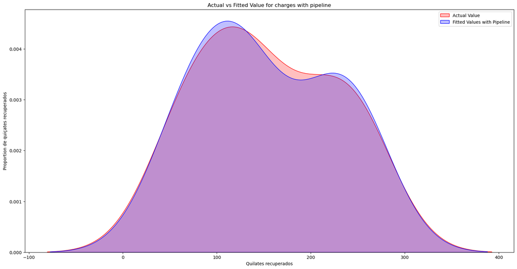

```python
plt.figure(figsize=(20, 10))

ax1 = srn   .kdeplot(Y_ter, color='r', label='Actual Value', fill=True)
srn.kdeplot(Yhat_pipe_ter, color='b', label='Fitted Values with Pipeline',fill=True, ax=ax1)

plt.title('Actual vs Fitted Value for charges with pipeline')
plt.xlabel('Quilates recuperados')
plt.ylabel('Proportion de quiçates recuperados')

plt.legend()

plt.show()
```

```python
R_squared = r2_score(Y_ter, pipe_ter.predict(feature_ter1))
print('R_squared:', R_squared)
```

```
R_squared: 0.9954218992148951
```

#### **Quinta Tarefa / 5º Task**

- Avaliação e Ajustamento do Modelo / Validation and Model Refinement

```python
features_ter2 =  ['Volume', 'Teor']
Z_ter2 = TER[features_ter2]
```

```python
x_train_ter, x_test_ter, y_train_ter, y_test_ter = train_test_split(Z_ter2, Y_ter, test_size=0.15, random_state=1)

print('Number of training samples:', x_train_ter.shape[0])
print('Number of test samples:', x_test_ter.shape[0])
```

```
Number of training samples: 12
Number of test samples: 3
```

```python
RidgeModelo_ter = Ridge(alpha=0.1)
RidgeModelo_ter.fit(x_train_ter, y_train_ter)
```

```
Ridge(alpha=0.1)
```

```python
R_squared_Ridge = r2_score(y_test_ter, RidgeModelo_ter.predict(x_test_ter))
print('The R-squared value is:', R_squared_Ridge)
```

```
The R-squared value is: -6.124595959242273
```

```python
pr_ter2 = PolynomialFeatures(degree=2)
x_train_pr_ter2 = pr_ter2.fit_transform(x_train_ter)
x_test_pr_ter2 = pr_ter2.fit_transform(x_test_ter)
pr_ter2
```

```
PolynomialFeatures()
```

```python
print(x_train_pr_ter2.shape)
print(x_test_pr_ter2.shape)
```

```
(12, 6)
(3, 6)
```

```python
RidgeModelo_ter.fit(x_train_pr_ter2, y_train_ter)
```

```
Ridge(alpha=0.1)
```

- **Treinamento / Training**

```python
Yhat_Ridge_Polly_ter = RidgeModelo_ter.predict(x_train_pr_ter2)
Yhat_Ridge_Polly_ter[0:5]
```

```
array([ 67.76882421, 197.50041005, 138.72503419, 113.69256284,
       237.6000601 ])
```

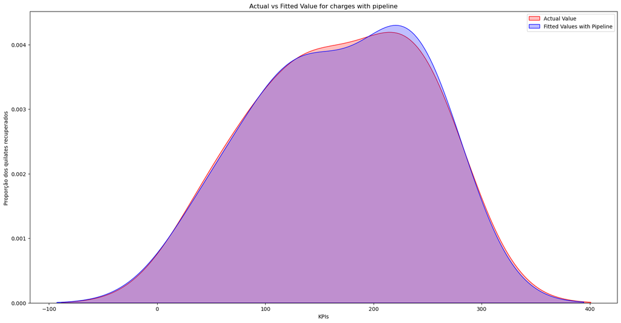

```python
plt.figure(figsize=(20, 10))

ax1 = srn.kdeplot(y_train_ter, color='r', label='Actual Value', fill=True)
srn.kdeplot(Yhat_Ridge_Polly_ter, color='b', label='Fitted Values with Pipeline', fill=True, ax=ax1)

plt.title('Actual vs Fitted Value for charges with pipeline')
plt.xlabel('KPIs')
plt.ylabel('Proporção dos quilates recuperados ')

plt.legend()

plt.show()
```

```python
R_squared_Ridge_Polly = r2_score(y_train_ter, Yhat_Ridge_Polly_ter)
print('The R-Squared value is:', R_squared_Ridge_Polly)
```

```
The R-Squared value is: 0.9945233481815032
```

- **Teste / Test**

```python
Yhat_Ridge_Polly_ter_test = RidgeModelo_ter.predict(x_test_pr_ter2)
Yhat_Ridge_Polly_ter_test[0:5]
```

```
array([ 89.3222646 , 120.72510193,  68.35849719])
```

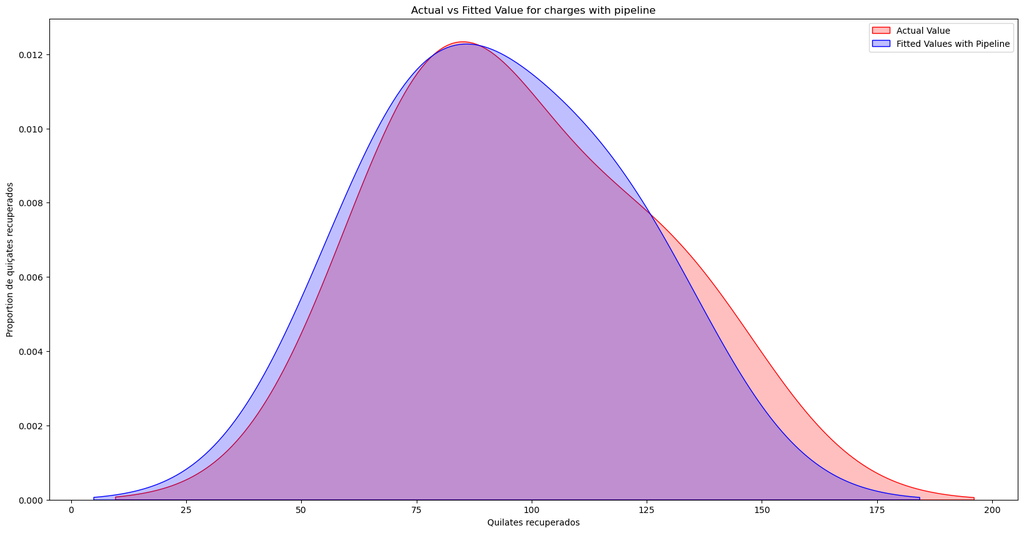

```python
plt.figure(figsize=(20, 10))

ax1 = srn.kdeplot(y_test_ter, color='r', label='Actual Value', fill=True)
srn.kdeplot(Yhat_Ridge_Polly_ter_test, color='b', label='Fitted Values with Pipeline',fill=True, ax=ax1)

plt.title('Actual vs Fitted Value for charges with pipeline')
plt.xlabel('Quilates recuperados')
plt.ylabel('Proportion de quiçates recuperados')

plt.legend()

plt.show()
```

```python
R_squared_Ridge_Polly = r2_score(y_test_ter, Yhat_Ridge_Polly_ter_test)
print('The R-Squared value is:', R_squared_Ridge_Polly)
```

```
The R-Squared value is: 0.9066704392338027
```

- **Validação Cruzada / Cross Validation**

```python
Rcross_Polly = cross_val_score(RidgeModelo_ter, x_train_pr_ter2, y_train_ter, cv = 3)
print('The mean of the folds are:', Rcross_Polly.mean())
```

```
The mean of the folds are: 0.9742340395504087
```

## **TERRAÇO FLUVIAL DEPOSITO / TERRACE FLUVIAL DEPOSIT**

```python
TER_FL = df.loc[df['Deposito'] == 'TER-FLUVIAL']
```

- **Regressão Linear Linear Regression**
- **Volume**

```python
x_ter_fl1 = TER_FL[['Volume']]
Y_ter_fl = TER_FL['Qts']
```

```python
lr_ter_fl1 = lm.fit(x_ter_fl1, Y_ter_fl)
lr_ter_fl1
```

```
LinearRegression()
```

```python
# Produce a prediction
Yhat_lr_ter_fl1 = lr_ter_fl1.predict(x_ter_fl1)
Yhat_lr_ter_fl1[0:5].round(2)
```

```
array([ 86.28, 185.36, 138.43, 280.82, 181.75])
```

```python
# Final Estimaded Linear for the model above
Yhat_lr_ter_fl1 = lr_ter_fl1.intercept_ + lr_ter_fl1.coef_ * TER_FL['Volume']
Yhat_lr_ter_fl1[0:5].round(2)
```

```
3      86.28
5     185.36
15    138.43
24    280.82
25    181.75
Name: Volume, dtype: float64
```

```python
# Calculate de R^2
R_squared_lr1 = r2_score(Y_ter_fl, lr_ter_fl1.predict(x_ter_fl1))
print('R_squared is:', R_squared_lr1)
```

```
R_squared is: 0.657854995770097
```

- **Teor**

```python
x_ter_fl2 = TER_FL[['Teor']]
```

```python
# Ajustar o modelo com uma nova variável
lr_ter_fl2 = lm.fit(x_ter_fl2, Y_ter_fl)
lr_ter_fl2
```

```
LinearRegression()
```

```python
# Produce a prediction
Yhat_lr_ter_lez2 = lr_ter_lez2.predict(x_ter_lez2)
Yhat_lr_ter_lez2[0:5].round(2)
```

```
array([156.44, 156.44, 140.  , 156.44, 287.99])
```

```python
# Produce a prediction
Yhat_lr_ter_fl2 = lr_ter_fl2.predict(x_ter_fl2)
Yhat_lr_ter_fl2[0:5].round(2)
```

```
array([189.33, 107.12, 238.66, 172.89, 222.21])
```

```python
# Final Estimaded Linear for the model above
qts_lr_ter_fl2 = lr_ter_fl2.intercept_ + lr_ter_fl2.coef_ * TER_FL['Teor']
qts_lr_ter_fl2[0:5].round(2)
```

```
3     189.33
5     107.12
15    238.66
24    172.89
25    222.21
Name: Teor, dtype: float64
```

```python
# Calculate de R^2
R_squared_lr2 = lr_ter_fl2.score(x_ter_fl2, Y_ter_fl)
print('R_squared is:', R_squared_lr2 )
```

```
R_squared is: 0.303943100026395
```

- **Multiple Linear Regression**:

```python
Z_ter_fl1 = TER_FL[['Volume', 'Teor']]
```

```python
lr_ter_fl3 = lm.fit(Z_ter_fl1, Y_ter_fl)
lr_ter_fl3
```

```
LinearRegression()
```

```python
# Produce a prediction
Yhat_lr_ter_fl3 = lr_ter_fl3.predict(Z_ter_fl1)
Yhat_lr_ter_fl3[0:5].round(2)
```

```
array([ 92.28, 118.5 , 178.54, 257.22, 205.27])
```

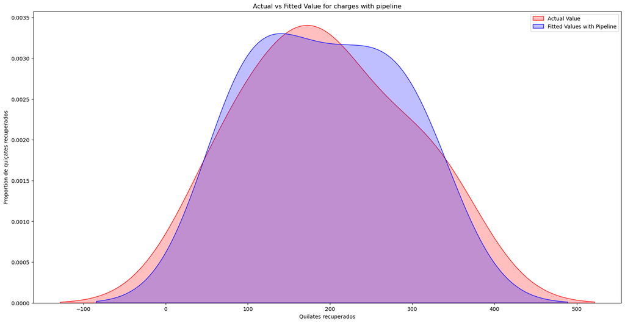

```python
plt.figure(figsize=(20, 10))

ax1 = srn   .kdeplot(Y_ter_fl, color='r', label='Actual Value', fill=True)
srn.kdeplot(Yhat_lr_ter_fl3, color='b', label='Fitted Values with Pipeline',fill=True, ax=ax1)

plt.title('Actual vs Fitted Value for charges with pipeline')
plt.xlabel('Quilates recuperados')
plt.ylabel('Proportion de quiçates recuperados')

plt.legend()

plt.show()
```

```python
R_squared_lr3 = lr_ter_fl3.score(Z_ter_fl1 , Y_ter_fl)
print('R_squared is:', R_squared_lr3)
```

```
R_squared is: 0.8391032532396834
```

**Regressão Polinomial / Polinomial Regresssion**

```python
# Create a polynomial feature obbject of degree 2
pr_ter_fl1 = PolynomialFeatures(degree=2)
print(pr_ter_fl1)
```

```
PolynomialFeatures()
```

```python
Z_ter_fl1.isnull().sum()
```

```
Volume    0
Teor      0
dtype: int64
```

```python
# Fit and transform the data into a polynomial
Z_pr_ter_fl1 = pr_ter_fl1.fit_transform(Z_ter_fl1)
print(Z_ter_fl1.shape)
print(Z_pr_ter_fl1.shape)
```

```
(8, 2)
(8, 6)
```

```python
input_ter_fl = [('Scale', StandardScaler()), ('Polynomial', PolynomialFeatures(include_bias=False)), ('model', LinearRegression())]
input_ter_fl
```

```
[('Scale', StandardScaler()),
 ('Polynomial', PolynomialFeatures(include_bias=False)),
 ('model', LinearRegression())]
```

```python
pipe_ter_fl = Pipeline(input_ter_fl)
pipe_ter_fl
```

```
Pipeline(steps=[('Scale', StandardScaler()),
                ('Polynomial', PolynomialFeatures(include_bias=False)),
                ('model', LinearRegression())])
```

```python
feature_ter_fl1 = Z_ter_fl1.astype(float)
pipe_ter_fl.fit(feature_ter_fl1, Y_ter_fl)
```

```
Pipeline(steps=[('Scale', StandardScaler()),
                ('Polynomial', PolynomialFeatures(include_bias=False)),
                ('model', LinearRegression())])
```

```python
Yhat_pipe_ter_fl = pipe_ter_fl.predict(feature_ter_fl1)
Yhat_pipe_ter_fl[0:5]
```

```
array([ 86.61666382,  99.3845915 , 128.64386775, 226.77490348,
       214.48073646])
```

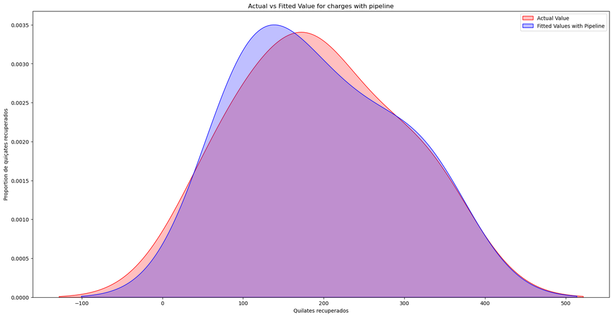

```python
plt.figure(figsize=(20, 10))

ax1 = srn.kdeplot(Y_ter_fl, color='r', label='Actual Value', fill=True)
srn.kdeplot(Yhat_pipe_ter_fl, color='b', label='Fitted Values with Pipeline',fill=True, ax=ax1)

plt.title('Actual vs Fitted Value for charges with pipeline')
plt.xlabel('Quilates recuperados')
plt.ylabel('Proportion de quiçates recuperados')

plt.legend()

plt.show()
```

```python
R_squared = r2_score(Y_ter_fl, pipe_ter_fl.predict(feature_ter_fl1))
print('R_squared:', R_squared)
```

```
R_squared: 0.9578863314975445
```

#### **Quinta Tarefa / 5 Task**

- Avaliação e Ajustamento do Modelo / Validation and Model Refinement

```python
features_ter_fl2 =  ['Volume', 'Teor']
Z_ter_fl2 = TER_FL[features_ter_fl2]
```

```python
x_train_ter_fl, x_test_ter_fl, y_train_ter_fl, y_test_ter_fl = train_test_split(Z_ter_fl2, Y_ter_fl, test_size=0.15, random_state=1)

print('Number of training samples:', x_train_ter_fl.shape[0])
print('Number of test samples:', x_test_ter_fl.shape[0])
```

```
Number of training samples: 6
Number of test samples: 2
```

```python
RidgeModelo_ter_fl = Ridge(alpha=0.1)
RidgeModelo_ter_fl.fit(x_train_ter_fl, y_train_ter_fl)
```

```
Ridge(alpha=0.1)
```

```python
R_squared_Ridge = r2_score(y_test_ter_fl, RidgeModelo_ter_fl.predict(x_test_ter_fl))
print('The R-squared value is:', R_squared_Ridge)
```

```
The R-squared value is: 0.13894825212537376
```

```python
pr_ter_fl2 = PolynomialFeatures(degree=2)
x_train_pr_ter_fl2 = pr_ter_fl2.fit_transform(x_train_ter_fl)
x_test_pr_ter_fl2 = pr_ter_fl2.fit_transform(x_test_ter_fl)
pr_ter_fl2
```

```
PolynomialFeatures()
```

```python
print(x_train_pr_ter_fl2.shape)
print(x_test_pr_ter_fl2.shape)
```

```
(6, 6)
(2, 6)
```

```python
RidgeModelo_ter_fl.fit(x_train_pr_ter_fl2, y_train_ter_fl)
```

```
Ridge(alpha=0.1)
```

- **Treinamento / Training**

```python
Yhat_Ridge_Polly_ter_fl = RidgeModelo_ter_fl.predict(x_train_pr_ter_fl2)
Yhat_Ridge_Polly_ter_fl[0:5]
```

```
array([109.70180576, 317.79181654,  96.98996825, 204.64542283,
       240.66728928])
```

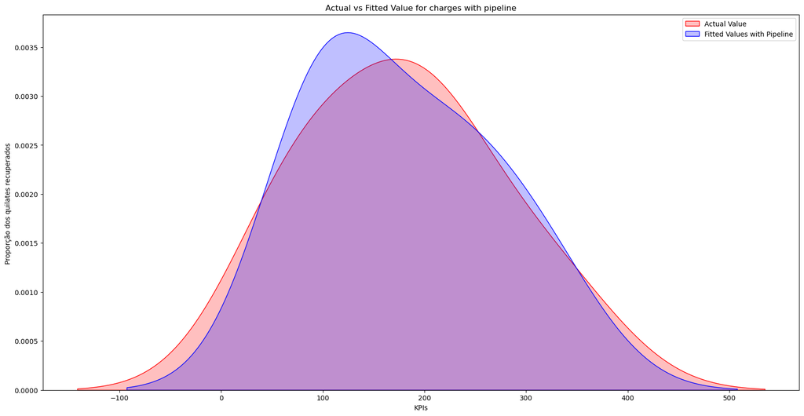

```python
plt.figure(figsize=(20, 10))

ax1 = srn.kdeplot(y_train_ter_fl, color='r', label='Actual Value', fill=True)
srn.kdeplot(Yhat_Ridge_Polly_ter_fl, color='b', label='Fitted Values with Pipeline', fill=True, ax=ax1)

plt.title('Actual vs Fitted Value for charges with pipeline')
plt.xlabel('KPIs')
plt.ylabel('Proporção dos quilates recuperados ')

plt.legend()

plt.show()
```

```python
R_squared_Ridge_Polly = r2_score(y_train_ter_fl, Yhat_Ridge_Polly_ter_fl)
print('The R-Squared value is:', R_squared_Ridge_Polly)
```

```
The R-Squared value is: 0.8618735179215754
```

- **Teste / Test**

```python
Yhat_Ridge_Polly_ter_fl_test = RidgeModelo_ter_fl.predict(x_test_pr_ter_fl2)
Yhat_Ridge_Polly_ter_fl_test[0:5]
```

```
array([313.33103033, 170.54437552])
```

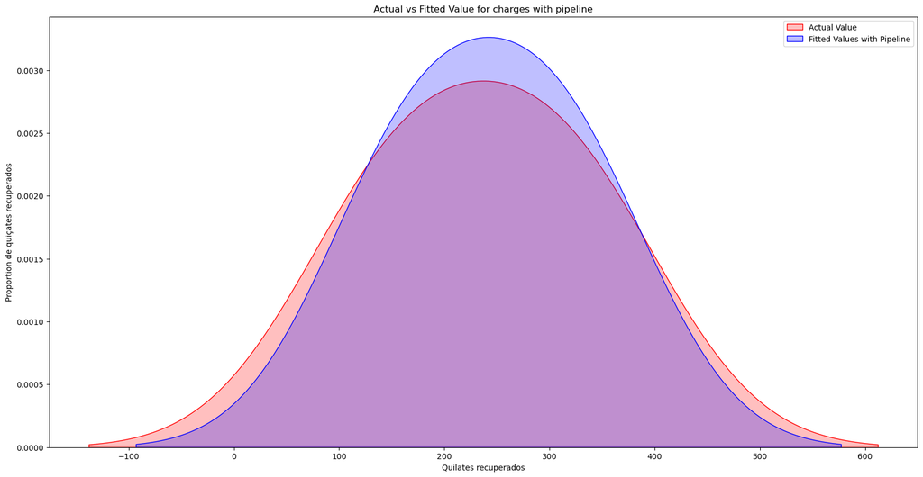

```python
plt.figure(figsize=(20, 10))

ax1 = srn.kdeplot(y_test_ter_fl, color='r', label='Actual Value', fill=True)
srn.kdeplot(Yhat_Ridge_Polly_ter_fl_test, color='b', label='Fitted Values with Pipeline',fill=True, ax=ax1)

plt.title('Actual vs Fitted Value for charges with pipeline')
plt.xlabel('Quilates recuperados')
plt.ylabel('Proportion de quiçates recuperados')

plt.legend()

plt.show()
```

```python
R_squared_Ridge_Polly = r2_score(y_test_ter_fl, Yhat_Ridge_Polly_ter_fl_test)
print('The R-Squared value is:', R_squared_Ridge_Polly)
```

```
The R-Squared value is: 0.9849799200615864
```

- **Validação Cruzada / Cross Validation**

```python
Rcross_Polly = cross_val_score(RidgeModelo_ter_fl, x_train_pr_ter_fl2, y_train_ter_fl, cv = 3)
print('The mean of the folds are:', Rcross_Polly.mean())
```

```
The mean of the folds are: -14.745744156794203
```

## **Conclusão:**

Com base na validação dos modelos, foi possível identificar quais abordagens de regressão oferecem maior precisão na previsão da recuperação de quilates para cada tipo de depósito aluvionar.

Esses resultados evidenciam que não há um modelo único que se destaque para todos os depósitos, mas sim abordagens específicas que maximizam a precisão dependendo das características de cada local.

Conclusões principais:

✔️ Alguns modelos apresentam desempenho consistente em múltiplos depósitos, sugerindo generalização eficaz.

✔️ Outros modelos demonstram alta precisão em depósitos específicos, permitindo previsões mais refinadas e estratégias de recuperação personalizadas.

Essa análise possibilita um planejamento estratégico mais assertivo na mineração aluvionar, otimizando a tomada de decisão, a previsão de produção e a eficiência operacional no setor.

[EN]

## **Conclusion:**

Based on the validation of the models, it was possible to identify which regression approaches offer greater accuracy in predicting carat recovery for each type of alluvial deposit.

These results show that there is no single model that stands out for all deposits, but rather specific approaches that maximize accuracy depending on the characteristics of each location.

Key findings:

✔️ Some models perform consistently across multiple deposits, suggesting effective generalization.

✔️ Other models demonstrate high accuracy in specific deposits, allowing for more refined predictions and customized recovery strategies.

This analysis enables more assertive strategic planning in alluvial mining, optimizing decision-making, production forecasting, and operational efficiency in the sector.